# HW: Applying Unsupervised Learning to the Cleveland Heart Dataset

## Pre-process the data

```matlab
% 1. Import spreadsheet as table
heart_data = readtable('cleveland.data_dec2019 - Copy.xlsx');
```

Warning: Column headers from the file were modified to make them valid MATLAB identifiers before creating variable names for the table. The original column headers are saved in the VariableDescriptions property.  
Set 'PreserveVariableNames' to true to use the original column headers as table variable names.

```matlab
% 2. Remove rows with missing values
heart_data = rmmissing(heart_data);

% 3. Normalize columns
norm_data = normalize(table2array(heart_data));
```

## Unsupervised analysis

1. Create a clustergram of the entire data (distance = correlation)
2. Create a PCA plot based on patients and another based on features
3. Find optimal number of patient groups with k-means clustering + silhouette analysis
4. Determine whether k-means can be used for diagnosis

```matlab
% 1. Create clustergram (distance = correlation)
heart_cg = clustergram(norm_data,...
    'RowLabels',heart_data.diseaseSeverity,...
    'ColumnLabels',heart_data.Properties.VariableNames,...
    'Standardize','column',...
    'RowPDist','correlation','ColumnPDist','correlation',...
    'Colormap',redbluecmap);
```

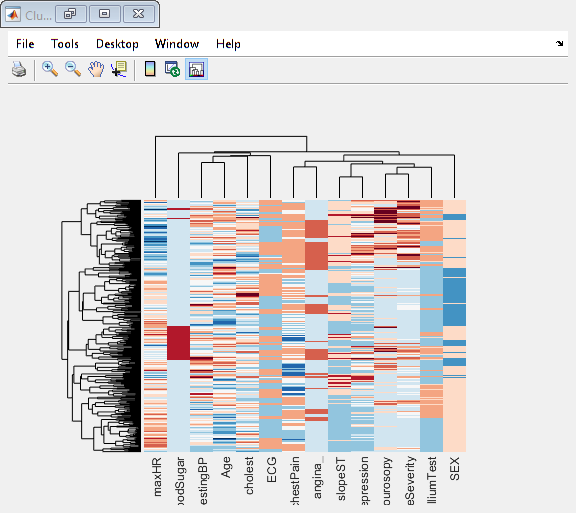

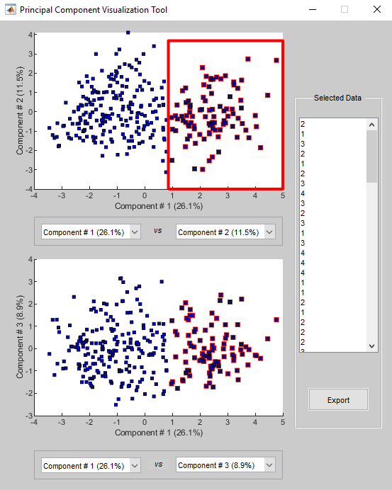

```matlab
% 2a. PCA for patients
mapcaplot(norm_data, heart_data.diseaseSeverity)
```

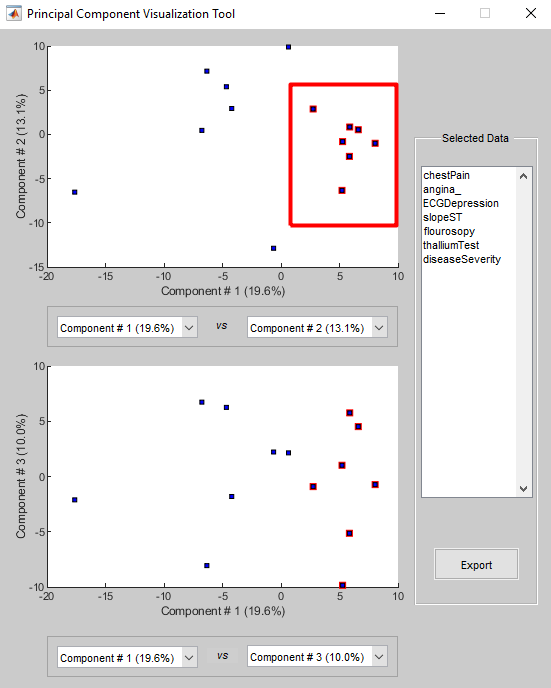

```matlab
% 2b. PCA for features
mapcaplot(norm_data',heart_data.Properties.VariableNames)
```

### Q&A

Question: Based on clustergram and PCA, how many distinct patient groups are there?

Answer: Clustergram: 4-5, PCA: 2

Question: Can the features (columns) be grouped into smaller set of PCs? If so, what are they?

Answer: Yes, these are: chestPain, angina_, ECGDepression, slopeST, flourosopy, thalliumTest, and diseaseSeverity

Question: Can patients with heart disease be further classified into smaller groups?

Answer: Yes, see images below:

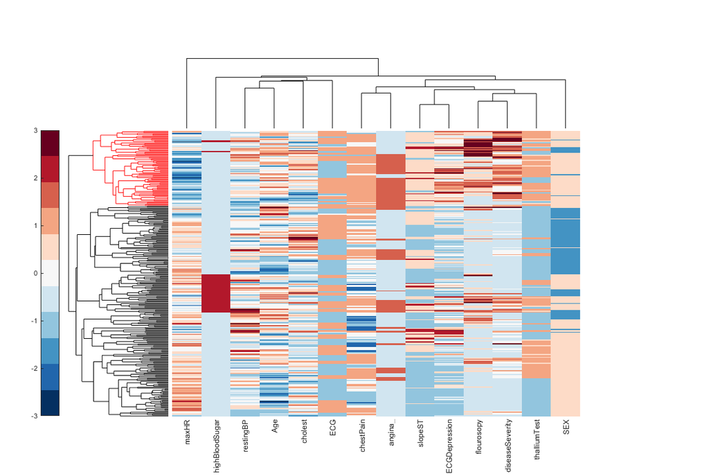

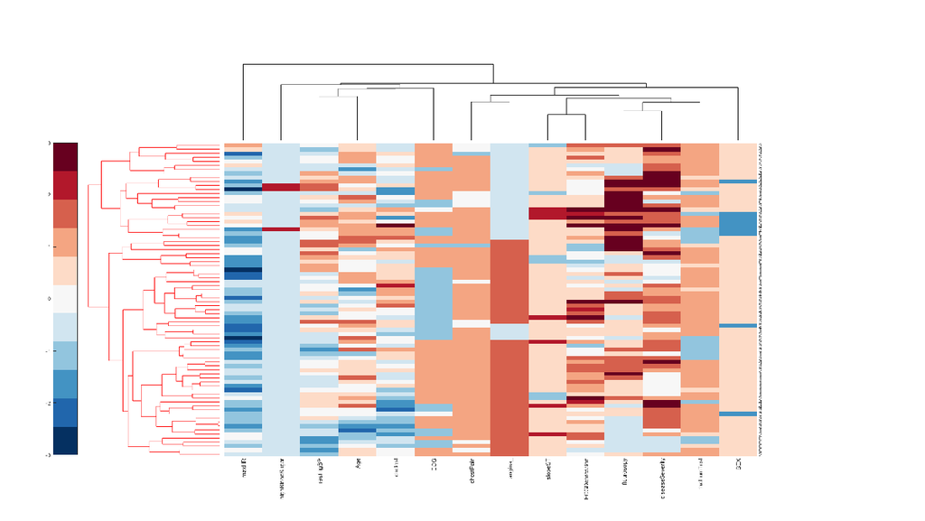

```matlab
% 3. k-means for determining optimal number of patient groups
k_values = 2:10;
X = table2array(heart_data(:,1:end));

% For-loop to calculate the silhouette statistic for different k values
n = length(k_values);   % number of k values
s_score = zeros(n,1);   % variable to store silhouette score values
for i = 1:n
    % Use the kmeans function to cluster patients into k clusters
    idx = kmeans(X,k_values(i));
    % Use the silhouette function to calculate silhouette values
    s = silhouette(X,idx);
    % Calculate the silhouette score by taking the mean
    s_score(i) = mean(s);
end
max(s_score)
```

ans = 0.5772

```matlab
k = find(s_score==max(s_score))+1
```

k = 2

Answer: Optimal k for grouping patients is k = 2.

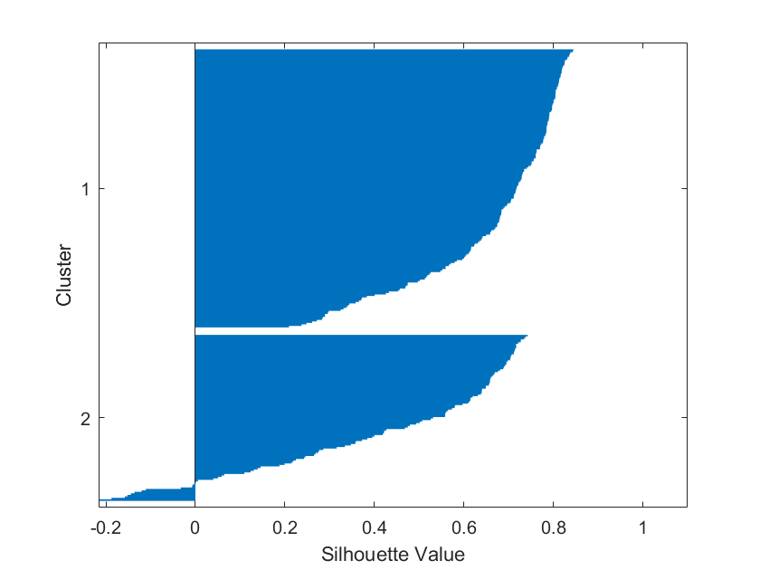

```matlab
% 4. k-means for diagnosis?
idx = kmeans(X,k);
silhouette(X,idx)
```

```matlab
% Vector for normal (0) vs. diseased (1)
heart_disease = zeros(size(heart_data,1),1);
heart_disease(heart_data.diseaseSeverity > 0) = 1;

% Cluster 1 (40.86% diseased)
c1 = heart_disease(idx == 1); sum(c1)/length(c1)
```

ans = 0.4086

```matlab
% Cluster 2 (54.95% diseased)
c2 = heart_disease(idx == 2); sum(c2)/length(c2)
```

ans = 0.5495

Answer: K-means is not a great tool to use for diagnosis (does not clearly separate normal and diseased patients).